# FigureYa323STpathseq

# 需求描述

# Demand description

通过[pathseq](https://gatk.broadinstitute.org/hc/en-us/articles/360035889911)分析得到空间转录组的微生物UMI，画出FIG 1。

Obtain microbial UMIs from spatial transcriptomics data through [pathseq](https://gatk.broadinstitute.org/hc/en-us/articles/360035889911) and visualize them in FIG 1.

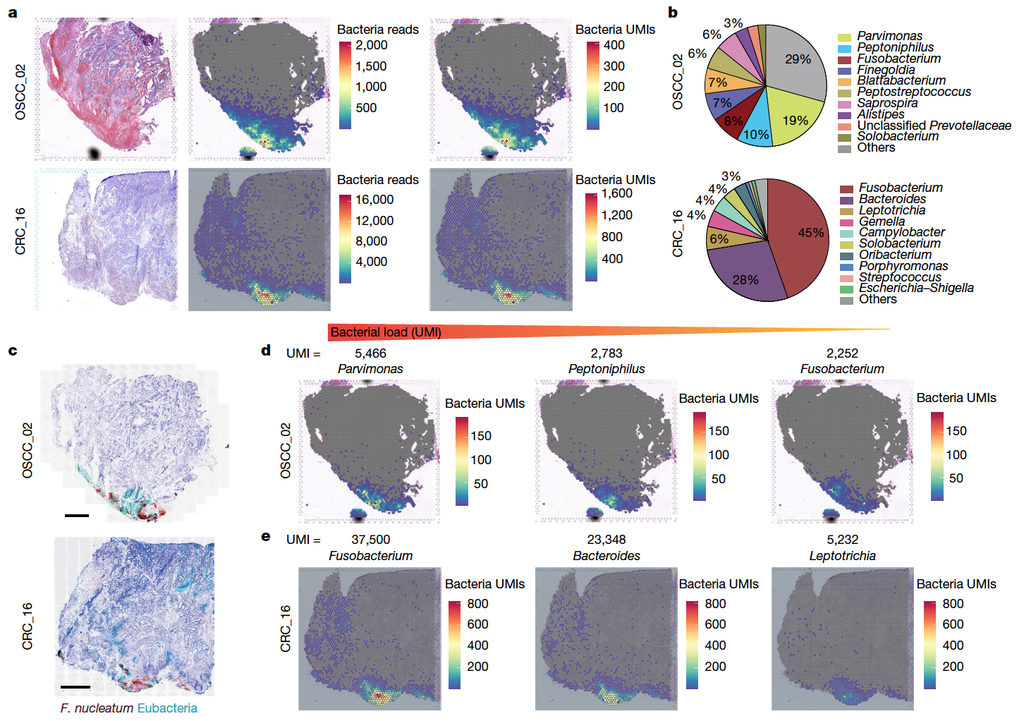

出自：https://www.nature.com/articles/s41586-022-05435-0

图1：评估肿瘤组织内细菌的空间分布。 a，人OSCC和CRC样本的10x Visium捕获切片中，肿瘤组织的苏木精-伊红（H&E）染色（左）、总细菌读数的空间分布（中）和总UMI转录本的空间分布（右）。 b，OSCC和CRC肿瘤的10x Visium RNA测序数据中检测到的前10个优势细菌属的饼图。 c，RNAscope-FISH成像显示在10x Visium切片后的连续切片中细菌在肿瘤组织中的分布。红色为具核梭杆菌（F. nucleatum）探针，青色为广谱细菌探针。比例尺：1 mm。 d，在10x Visium OSCC样本数据中检测到的微小单胞菌、嗜胨菌（Peptoniphilus）和梭杆菌（Fusobacterium）UMI的空间分布。 e，在10x Visium CRC样本数据中检测到的梭杆菌（Fusobacterium）、拟杆菌（Bacteroides）和纤毛菌（Leptotrichia）UMI的空间分布。

Source: https://www.nature.com/articles/s41586-022-05435-0

Fig. 1: Assessing the spatial distribution of intratumoral bacteria throughout the tumour tissue. a, Haematoxylin and eosin (H&E) staining (left), spatial distribution of total bacterial reads (centre) and total UMI transcripts (right) throughout the tumour tissue in the 10x Visium capture slides from human OSCC and CRC specimens. b, Pie chart of the top 10 most dominant bacterial genera detected in the 10x Visium RNA-sequencing data from the OSCC and CRC tumours. c, RNAscope-FISH imaging showing the distribution of bacteria across the tumour tissue in a sequential slide following the 10x Visium section. The F.nucleatum probe is red and the eubacterial probe is cyan. Scale bars, 1 mm. d, Spatial distribution of Parvimonas, Peptoniphilus and Fusobacterium UMIs detected in the 10x Visium OSCC specimen data. e, Spatial distribution of Fusobacterium, Bacteroides and Leptotrichia UMIs detected in the 10x Visium CRC specimen data.

# 应用场景

# Application scenarios

分析空间转录组测序文件中的微生物组信息。

本流程仅在样本支持的情况下能够提取微生物组信息，绝大部分的公开数据集是不能满足该条件的。

关于如何才能生成符合条件的样本数据，请参看原文献的protocol或咨询测序方。

Analyzing microbiome information from spatial transcriptomics sequencing files.

This pipeline can only extract microbiome data if the samples meet specific requirements. Most publicly available datasets do not satisfy these conditions.

For guidance on generating compatible sample data, please refer to the original protocol in the cited literature or consult the sequencing provider.

# 环境设置

# Environment Setup

**注意：**该流程对内存和存储要求很高，内存应当在200G以上，可支配存储应在300G以上（150G参考基因组+每个样本30G~100G数据量）

在Codes/S2.pathseq.sh中修改gatk变量，以保证能够正常调用gatk软件

gatk变量可定义为”gatk”或”java -Xmx100G -jar path/to/gatk.jar”

**Note:** This process has high memory and storage requirements. The memory should be at least 200G, and available storage should exceed 300G (150G reference genome + 30G~100G data per sample).

Modify the gatk variable in Codes/S2.pathseq.sh to ensure proper calling of the gatk software.

The gatk variable can be defined as either “gatk” or “java -Xmx100G -jar path/to/gatk.jar”.

# 输入文件

# Input Files

需要空间转录组样本测序数据和参考信息。

**1.** 空间转录组样本的数据信息（包括FASTQ，tiff）

下载地址：https://github.com/FredHutch/Galeano-Nino-Bullman-Intratumoral-Microbiota_2022

在InputData下按样本放置输入文件，以样本CRC_16为例，相关文件放在InputData/CRC_16路径下，即

- InputData/CRC_16/CRC_16_*.fastq.gz
- InputData/CRC_16/CRC_16.tiff
- InputData/CRC_16/V10S15-020.gpr

在InputData/sample_sheet.csv文件中写入样本信息，包括sample、slide、area。

**2.** 参考信息：spaceranger参考基因组和pathseq参考组

切换到Reference目录下，运行BuildReference.sh脚本，脚本会自动下载所需参考组，并解压到既定位置。

Spatial transcriptomics sample sequencing data and reference information are required.

**1.** Data information for spatial transcriptomics samples (including FASTQ and TIFF files)

Download address: https://github.com/FredHutch/Galeano-Nino-Bullman-Intratumoral-Microbiota_2022

Input files should be placed under the InputData directory according to the sample names. Taking sample CRC_16 as an example, the relevant files are stored in the InputData/CRC_16 path, including:

- InputData/CRC_16/CRC_16_*.fastq.gz
- InputData/CRC_16/CRC_16.tiff
- InputData/CRC_16/V10S15-020.gpr

Sample information (including sample, slide, and area) should be recorded in the InputData/sample_sheet.csv file.

**2.** Reference information: spaceranger reference genome and pathseq reference database

Switch to the Reference directory and run the BuildReference.sh script. The script will automatically download the required reference datasets and extract them to the designated locations.

# 分析过程

# Analysis Process

运行STpathseq.sh脚本，【在主目录下运行STpathseq.sh】

或根据STpathseq.sh的用法分步运行Codes/S1.spaceranger.sh、Codes/S2.pathseq.sh和Codes/S3.postprocess.sh

关于Codes文件夹下S1~S3.sh脚本的功能和用法介绍 【在主目录下bash *.sh】

- S1.spaceranger.sh 参数sample（样本名称），slide，area，slide和area需询问测序方
- S2.pathseq.sh 参数sample（样本名称）
- S3.postprocess.sh 参数sample（样本名称）

Run the STpathseq.sh script [run STpathseq.sh in the main directory]

Or follow the steps in STpathseq.sh to run Codes/S1.spaceranger.sh, Codes/S2.pathseq.sh, and Codes/S3.postprocess.sh separately

Description of the functions and usage of the S1~S3.sh scripts in the Codes folder [run bash *.sh in the main directory]

- S1.spaceranger.sh Parameters: sample (sample name), slide, area (slide and area need to be confirmed with the sequencing provider)
- S2.pathseq.sh Parameter: sample (sample name)
- S3.postprocess.sh Parameter: sample (sample name)

# 输出文件

# Output Files

Seurat对象【Results/*/outs/ST.seu.rds】，文件较大，从百度网盘下载https://pan.baidu.com/s/1BnnoAelzwYhIWjxpKcXWHg?pwd=frhw，下载后保存到`STpathseq/Results/CRC_16/outs/`文件夹下

Seurat object 【Results/*/outs/ST.seu.rds】, large file size, download from Baidu Netdisk https://pan.baidu.com/s/1BnnoAelzwYhIWjxpKcXWHg?pwd=frhw, after downloading save to `STpathseq/Results/CRC_16/outs/` folder

微生物组RNA总量空间分布图【Results/*/outs/*TotalMicrobe.pdf】

Spatial distribution map of total microbial RNA【Results/*/outs/*TotalMicrobe.pdf】

[figure not shown]

# 会话信息